# Linear regression - Mathematical framework

# Laplace and Gauss estimators

## What will we learn in this empirical exercise ?

1. Computing the OLS estimator for a dataset.
2. Finding the OLS estimator using an optimization procedure.
3. Finding the Laplace’s estimator using an optimization procedure.
4. Computing the $R^2$ and relating it with the empirical correlation.

# Theory behind the empirical exercise

We consider the CAPM given by,

$$y_t = \beta_1 + \beta_2 x_t + \epsilon_t,$$
in which $y_t$ and $x_t$ stand for the excess returns of a stock and of the market, respectively. To estimate the linear coefficients, we minimize the sum of squared residuals (SSR) that is expressed as
$$\text{min} \sum_{t=1}^{T}\epsilon_t^2 = \text{min} \sum_{t=1}^{T}(y_t - \beta_1 - \beta_2 x_t)^2.$$
Alternatively, we can minimize the sum of the absolute residuals as proposed by Laplace:
$$\text{min} \sum_{t=1}^{T}|\epsilon_t| = \text{min} \sum_{t=1}^{T}|y_t - \beta_1 - \beta_2 x_t|.$$
On one hand, minimizing the SSR leads to an analytical formula which is given by $\hat{\beta}_2 = \frac{\sum_{t=1}^{T}(x_t-\bar{x})(y_t - \bar{y})}{\sum_{t=1}^T (x_t - \bar{x})^2}$ and $\hat{\beta}_1 = \bar{y} - \hat{\beta}_2 \bar{x}$ in which $\bar{x}=\frac{1}{T}\sum_{t=1}^{T}x_t$, $\bar{y}=\frac{1}{T}\sum_{t=1}^{T}y_t$. On the other hand, the Laplace’s estimator does not exhibit a closed form and the estimate are obtained with an optimization method.

Eventually, the fit of a regression is typically assessed with the coefficient of determination, hereafter $R^2$. It is defined as follows:

$$R^2 = 1 - \frac{\sum_{t=1}^{T}\hat{\epsilon}_t^2}{\sum_{t=1}^{T}(y_t - \bar{y})^2}.$$
There is an exact equivalence between the coefficient of determination and the empirical correlation of the fitted values. In particular, we have
$$\rho_{\hat{y},y}^2 \equiv \text{Corr}(\hat{y},y)^2= \big(\frac{\sum_{t=1}^{T}(\hat{y}_t-\bar{\hat{y}})(y_t-\bar{y})}{\sqrt{\sum_{t=1}^{T}(y_t-\bar{y})^2} \sqrt{\sum_{t=1}^{T}(\hat{y}_t-\bar{\hat{y}})^2}}\big)^2 = R^2$$
For a simple linear regression (when we have one explanatory variable), we also have another equivalence between the empirical correlation and the coefficient of determination given by
$$\rho_{x,y}^2 \equiv \text{Corr}(x,y)^2 = R^2$$

## From theory to practice

We start by loading the data. In this exercise, we consider a simple CAPM in which the free rate is set to 0. We have returns from Amazon and from the S&P 500 which is typically used to approximate the market return.

```python
import matplotlib.pyplot as plt
import pandas as pd
import numpy as np
from scipy.stats import norm
from numpy.linalg import inv
from scipy.optimize import minimize
from scipy.stats import pearsonr

url = "https://raw.githubusercontent.com/adufays/GDP_expectancy/main/CAPM%20Exercise.csv"
data = pd.read_csv(url,sep=",")


get_data = np.array(data,ndmin=2,dtype=float)
df_ret=pd.DataFrame(get_data[:,1:(np.size(get_data,1)+1)],columns=data.columns[1:(np.size(get_data,1)+1)])
y = get_data[:,1]
x = get_data[:,2]
```

We first compute the OLS estimate:

```python
x_bar = np.mean(x)
y_bar = np.mean(y)
beta2 = np.dot(x-x_bar,y-y_bar)/np.dot(x-x_bar,x-x_bar)
beta1 = y_bar - beta2*x_bar
df_beta=pd.DataFrame(np.array((beta1,beta2),ndmin=2),columns=["beta1","beta2"])
print(df_beta)
```

```
##       beta1     beta2
## 0  0.066157  1.102894
```

Then, we visualize the linear regression. To do so, we plot the series and add a line with the intercept and the slope given by $\hat{\beta}_1$ and $\hat{\beta}_2$, respectively.

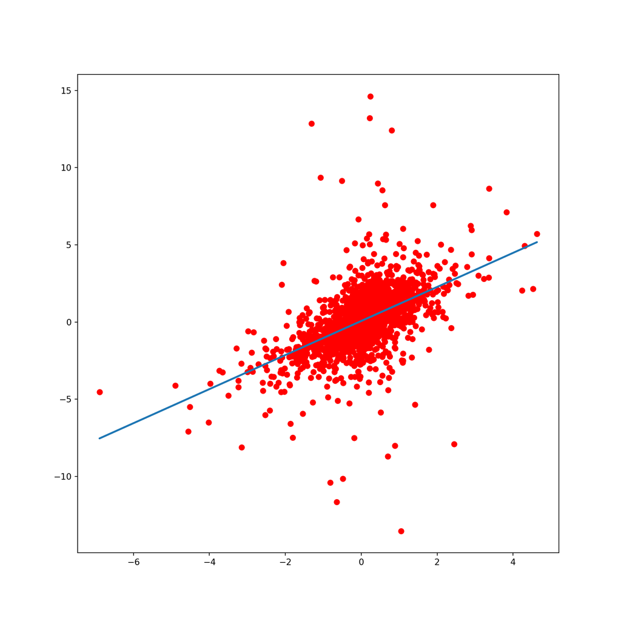

```python
# Create figure and plot space
fig, ax = plt.subplots(figsize=(10, 10))
# Add x-axis and y-axis
ax.scatter(x,y,color='red')
plt.plot(x,beta1 + beta2*x,linewidth=2)
```

We compare the OLS estimates with the Laplace’s ones. First, we need to compute the Laplace’s estimates. We shall code a function that computes the sum of absolute residuals and optimize it. We will do the same with a function that computes the sum of squared residuals to show that we obtain the same estimates as those above.

```python
#### Laplace
def Laplace_error(beta,y,x):
    return(np.sum(np.abs(y-beta[0]-beta[1]*x)))

### Sum of squared residuals
def SSR_error(beta,y,x):
    eps= y-beta[0]-beta[1]*x
    return(np.dot(eps,eps))

beta0=np.asarray((0.1,0.1))
## Optimization of the Laplace's function using an optimization algorithm:
MLE_Laplace=minimize(Laplace_error,beta0,method="BFGS",args=(y,x))
## Optimization of the SSR function using an optimization algorithm:
MLE_Gauss=minimize(SSR_error,beta0,method="BFGS",args=(y,x))
beta_all = np.asarray([np.asarray((beta1,beta2)),MLE_Gauss.x,MLE_Laplace.x])

df_beta_all=pd.DataFrame(np.reshape(beta_all,(1,6)),columns=["beta1","beta2","Optim - beta1","Optim - beta1","Lap - beta1","Lap - beta2"])
print(df_beta_all)
```

```
##       beta1     beta2  Optim - beta1  Optim - beta1  Lap - beta1  Lap - beta2
## 0  0.066157  1.102894       0.066157       1.102894     0.025773     1.129737
```

As expected, the Laplace’s estimates are different from the OLS estimates.

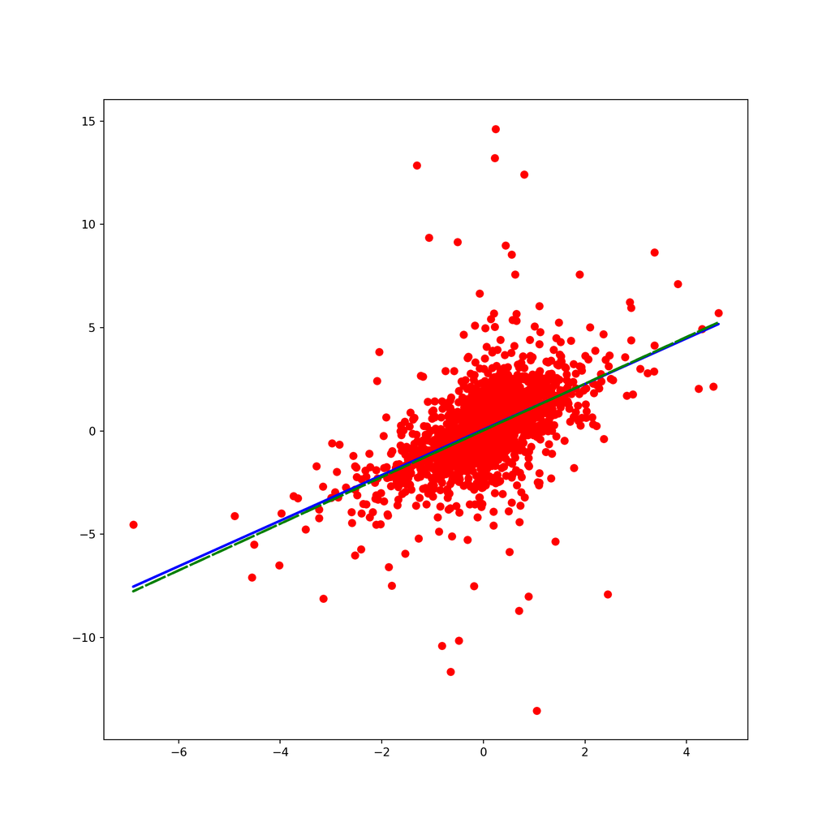

```python
# Create figure and plot space
fig, ax = plt.subplots(figsize=(10, 10))
# Add x-axis and y-axis
ax.scatter(x,y,color='r')
plt.plot(x,beta1 + beta2*x,'-b',linewidth=2)
plt.plot(x,MLE_Laplace.x[0] + MLE_Laplace.x[1]*x,'-.g',linewidth=2)
```

We now turn to the coefficient of determination. First, we compute the fitted values and compute the correlation between the fitted values and the dependent variable.

```python
y_fit = beta1 + beta2*x
rho_y,_ = pearsonr(y,y_fit)
print(rho_y)
```

```
## 0.5241862311459782
```

```python
r_sq = 1-SSR_error(MLE_Gauss.x,y,x)/SSR_error(np.asarray((y_bar,0)),y,x)
print(r_sq)
```

```
## 0.27477120492302487
```

```python
print(rho_y**2)
```

```
## 0.27477120492302487
```

The coefficient of determination is the square of the empirical correlation. In a linear regression with one explanatory variable, the coefficient of determination is also equal to the square of the correlation between the dependent variable and the explanatory variable.

```python
rho_x,_ = pearsonr(y,x)
print(rho_x**2)
```

```
## 0.27477120492302487
```

Again, we find the coefficient of determination.